# Tutorial 02 — Growth Functions and Nutrient Dynamics

**Prerequisites:** Tutorial 01 — Your First Simulation

The single most important modelling choice in pbisim is how bacterial growth depends on the environment. This tutorial covers all five built-in growth functions, explains when the nutrient state `S` is meaningful, and introduces natural death and biomass recycling.

**What you will learn**

1. How the growth signal `frac` enters the ODE
2. The five built-in growth functions and their use cases
3. When to freeze `S` with `track_nutrients=False`
4. Nutrient recycling (`recycle_fraction`) and its biological basis
5. Natural death (`death_rate_B`, `death_rate_D`)

## 1 Imports

```python
import numpy as np
import matplotlib.pyplot as plt

from pbisim import (ModelBuilder, PBIModel, solve_ode,
                    constant_growth, logistic_growth, monod_growth,
                    monod_logistic_growth, gompertz_growth)
```

## 2 The growth signal `frac`

Every growth function has the signature

```
frac = growth_fn(S, B, config)   # returns a float in [0, 1]
```

and enters the bacterium ODE as

```
dB/dt = growth_rate × frac × B  +  other terms
```

The choice of growth function decides *what limits bacterial proliferation*:

| Function | Limiting factor | `track_nutrients` |
| --- | --- | --- |
| `monod_growth` (default) | Nutrient concentration S (Michaelis–Menten) | **True** (S decreases) |
| `monod_logistic_growth` | Nutrient AND population density | **True** |
| `gompertz_growth` | Nutrient concentration S (Gompertz shape) | **True** |
| `logistic_growth` | Population density only | **False** (S irrelevant) |
| `constant_growth` | None (maximum rate always) | **False** |

## 3 Side-by-side comparison (no phage)

We run a phage-free model with each growth function to compare bacterial growth curves in isolation. All models share the same initial bacteria, and we turn off phage to isolate the growth dynamics.

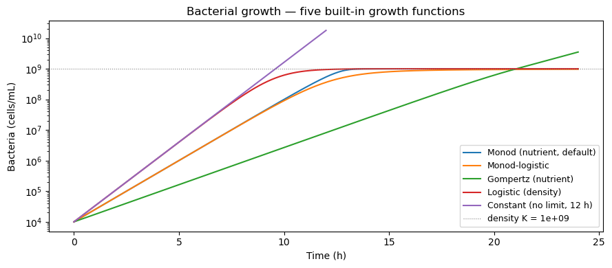

```python
# Constant growth is unbounded and causes numerical overflow beyond ~12 h;
# we keep the comparison window short.  Density-limited models are shown
# separately over a longer window to reveal their plateau behaviour.
T_END  = 12.0          # h — short enough for finite constant-growth values
DT     = 0.1
B0     = np.array([1e4])      # sparse inoculum to see full growth curve
K      = 1e9           # carrying capacity (cells/mL) for density-limited models
Ks     = 0.3           # Monod half-saturation constant

def _run_growth(builder, t_end=T_END):
    cfg = builder.build()
    return solve_ode(
        PBIModel(cfg, initial_B=B0, initial_P=np.zeros(0), initial_S=1.0),
        t_end=t_end, dt=DT,
    )

# 1. Monod — nutrient-limited (default); plateau from nutrient depletion
r_monod = _run_growth(
    ModelBuilder(n_bacteria=1, n_phages=0)
    .with_growth_rates(1.2, bacteria_to_resource_ratio=1e9)
    .with_nutrient(monod_constant=Ks, recycle_fraction=0.0),
    t_end=24.0,
)

# 2. Monod-logistic — nutrient AND density limited
r_monod_log = _run_growth(
    ModelBuilder(n_bacteria=1, n_phages=0)
    .with_growth_rates(1.2, bacteria_to_resource_ratio=1e9)
    .with_growth_function(monod_logistic_growth)
    .with_nutrient(monod_constant=Ks, carrying_capacity=K, recycle_fraction=0.0),
    t_end=24.0,
)

# 3. Logistic — density limited, no nutrient tracking
# track_nutrients=False requires a non-nutrient dormancy signal.
r_logistic = _run_growth(
    ModelBuilder(n_bacteria=1, n_phages=0)
    .with_growth_rates(1.2)
    .with_growth_function(logistic_growth)
    .with_dormancy(dormancy_signal="density", resuscitation_signal="density")
    .with_nutrient(carrying_capacity=K, track_nutrients=False),
    t_end=24.0,
)

# 4. Constant — maximum rate, no limiting factor.
# Run over a SHORT window only: unbounded exponential overflows beyond ~12 h.
r_constant = _run_growth(
    ModelBuilder(n_bacteria=1, n_phages=0)
    .with_growth_rates(1.2)
    .with_growth_function(constant_growth)
    .with_dormancy(dormancy_signal="constant", resuscitation_signal="constant")
    .with_nutrient(track_nutrients=False),
    t_end=T_END,   # 12 h only
)

# 5. Gompertz — nutrient-limited, Gompertz-shaped response.
# carrying_capacity here is a *nutrient* threshold (same units as S), not
# a cell-density ceiling.  Use track_nutrients=True (S is consumed).
r_gompertz = _run_growth(
    ModelBuilder(n_bacteria=1, n_phages=0)
    .with_growth_rates(1.2, bacteria_to_resource_ratio=1e9)
    .with_growth_function(gompertz_growth)
    .with_nutrient(monod_constant=Ks, carrying_capacity=0.1,  # nutrient threshold
                   recycle_fraction=0.0),
    t_end=24.0,
)

fig, ax = plt.subplots(figsize=(9, 4))
for label, res, color in [
    ("Monod (nutrient, default)",  r_monod,     "C0"),
    ("Monod-logistic",             r_monod_log, "C1"),
    ("Gompertz (nutrient)",        r_gompertz,  "C2"),
    ("Logistic (density)",         r_logistic,  "C3"),
    ("Constant (no limit, 12 h)", r_constant,  "C4"),
]:
    ax.semilogy(res.time, np.maximum(res.get("B0"), 1), color=color, label=label)

ax.axhline(K, ls=":", color="gray", lw=0.8, label=f"density K = {K:.0e}")
ax.set(xlabel="Time (h)", ylabel="Bacteria (cells/mL)",
       title="Bacterial growth — five built-in growth functions")
ax.legend(fontsize=9)
plt.tight_layout()
plt.show()
# Gompertz and Monod both use S as the limiting signal but with different
# functional forms; logistic uses population density; constant is unbounded.
```

## 4 When to use `track_nutrients=False`

With Monod growth, bacterial growth is limited by nutrient `S`, which is consumed as bacteria grow. This creates a natural carrying capacity — bacteria stop growing once `S` is depleted.

With logistic or constant growth the model does **not** use `S` to limit growth, so the nutrient state is biologically meaningless. Setting `track_nutrients=False` freezes `S` at its initial value (`dS/dt = 0`), preventing spurious depletion.

**pbisim validates this for you:** if you set `track_nutrients=False` but use the default nutrient-dependent dormancy functions, you will get a `ValueError` pointing to the inconsistency (see example below).

### 4.1 Nutrient trajectory: Monod vs. frozen

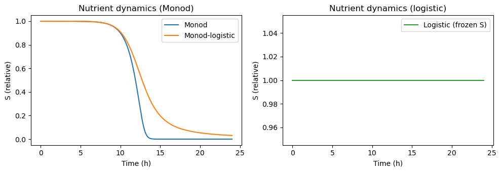

```python
# Monod: S decreases as bacteria grow
fig, axes = plt.subplots(1, 2, figsize=(10, 3.5))

ax = axes[0]
for label, res in [("Monod", r_monod), ("Monod-logistic", r_monod_log)]:
    ax.plot(res.time, res.get("S"), label=label)
ax.set(xlabel="Time (h)", ylabel="S (relative)", title="Nutrient dynamics (Monod)")
ax.legend()

# Logistic: S stays at 1.0 (frozen)
ax = axes[1]
ax.plot(r_logistic.time, r_logistic.get("S"), "C2", label="Logistic (frozen S)")
ax.set(xlabel="Time (h)", ylabel="S (relative)", title="Nutrient dynamics (logistic)")
ax.legend()

plt.tight_layout()
plt.show()
```

```python
# Validating the consistency rule
import warnings

# Correct usage: density-based dormancy when track_nutrients=False
cfg_ok = (
    ModelBuilder(n_bacteria=1, n_phages=0)
    .with_growth_rates(1.2)
    .with_growth_function(logistic_growth)
    .with_dormancy(dormancy_rate=0.05, resuscitation_rate=0.1,
                   dormancy_signal="density", resuscitation_signal="density")
    .with_nutrient(carrying_capacity=1e9, track_nutrients=False)
    .build()
)
print("OK: density-based dormancy is compatible with track_nutrients=False")

# Incorrect usage: nutrient-dependent dormancy with track_nutrients=False
try:
    cfg_bad = (
        ModelBuilder(n_bacteria=1, n_phages=0)
        .with_growth_rates(1.2)
        .with_growth_function(logistic_growth)
        .with_nutrient(track_nutrients=False)  # default dormancy is nutrient-dependent!
        .build()
    )
    PBIModel(cfg_bad, initial_B=np.array([1e6]), initial_P=np.zeros(0))
except ValueError as e:
    print(f"ValueError caught: {e}")
```

```
OK: density-based dormancy is compatible with track_nutrients=False
ValueError caught: track_nutrients=False freezes S, but the effective dormancy function (nutrient_dependent_dormancy (default)) depends on S.  Switch to density_dependent_dormancy or constant_dormancy, or set track_nutrients=True.
```

## 5 Natural death (`death_rate_B`)

Bacteria die at a baseline rate from metabolic stress and cell wall turnover even without phage or immune clearance. `death_rate_B` (h⁻¹) subtracts from the net growth rate of active bacteria.

> `death_rate_D` (death from the *deepest dormancy layer*) interacts with dormancy cycling and nutrient recycling to produce oscillatory dynamics. That demo appears in **Tutorial 03** after dormancy is introduced.

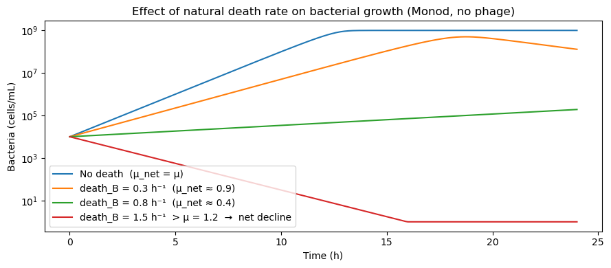

```python
fig, ax = plt.subplots(figsize=(9, 4))

for (dB, color, label) in [
    (0.0,  "C0", "No death  (μ_net = μ)"),
    (0.3,  "C1", "death_B = 0.3 h⁻¹  (μ_net ≈ 0.9)"),
    (0.8,  "C2", "death_B = 0.8 h⁻¹  (μ_net ≈ 0.4)"),
    (1.5,  "C3", "death_B = 1.5 h⁻¹  > μ = 1.2  →  net decline"),
]:
    death_kw = {"death_rate_B": dB} if dB > 0 else {}
    cfg_d = (
        ModelBuilder(n_bacteria=1, n_phages=0)
        .with_growth_rates(1.2, bacteria_to_resource_ratio=1e9)
        .with_death(**death_kw)
        .with_nutrient(monod_constant=0.3, recycle_fraction=0.0)
        .build()
    )
    res_d = solve_ode(
        PBIModel(cfg_d, initial_B=np.array([1e4]),
                 initial_P=np.zeros(0), initial_S=1.0),
        t_end=24.0, dt=0.1,
    )
    ax.semilogy(res_d.time, np.maximum(res_d.get("B0"), 1), color=color, label=label)

ax.set(xlabel="Time (h)", ylabel="Bacteria (cells/mL)",
       title="Effect of natural death rate on bacterial growth (Monod, no phage)")
ax.legend()
plt.tight_layout()
plt.show()
```

## 6 Nutrient recycling (`recycle_fraction`)

When bacteria die, their cellular contents are released back to the nutrient pool. The fraction returned is `recycle_fraction` (0–1, default 0.5).

Recycling only makes a difference when bacteria are actively dying **and** surviving bacteria can exploit the released nutrients. The clearest demo uses natural death alone — no phage are needed and none have been introduced yet.

With `death_rate_B = 0.8 h⁻¹` (just below μ = 1.2):

> `recycle_fraction = 0.0` is appropriate for in-vivo models (nutrients leave the site) or when using density-based growth functions (`track_nutrients=False`).

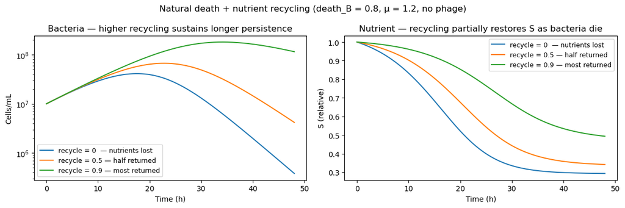

```python
fig, axes = plt.subplots(1, 2, figsize=(12, 4))

for rf, color, label in [
    (0.0, "C0", "recycle = 0  — nutrients lost"),
    (0.5, "C1", "recycle = 0.5 — half returned"),
    (0.9, "C2", "recycle = 0.9 — most returned"),
]:
    cfg_rf = (
        ModelBuilder(n_bacteria=1, n_phages=0)
        .with_growth_rates(1.2, bacteria_to_resource_ratio=1e9)
        .with_death(death_rate_B=0.8)   # moderate death provides biomass to recycle
        .with_nutrient(monod_constant=0.3, recycle_fraction=rf)
        .build()
    )
    res_rf = solve_ode(
        PBIModel(cfg_rf,
                 initial_B=np.array([1e7]),   # dense enough to deplete nutrients
                 initial_P=np.zeros(0), initial_S=1.0),
        t_end=48.0, dt=0.1,
    )
    axes[0].semilogy(res_rf.time, np.maximum(res_rf.get("B0"), 1),
                     color=color, label=label)
    axes[1].plot(res_rf.time, res_rf.get("S"), color=color, label=label)

axes[0].set(xlabel="Time (h)", ylabel="Cells/mL",
            title="Bacteria — higher recycling sustains longer persistence")
axes[1].set(xlabel="Time (h)", ylabel="S (relative)",
            title="Nutrient — recycling partially restores S as bacteria die")
for ax in axes: ax.legend(fontsize=9)
plt.suptitle("Natural death + nutrient recycling (death_B = 0.8, μ = 1.2, no phage)")
plt.tight_layout()
plt.show()
```

## 7 Summary and decision guide

[output not shown]

**Next tutorial:** *Dormancy* — depth layers, entry/exit functions, and interaction with phage adsorption.